# Homework 10

Grace Smith

2023-04-05

## Question 1

Using a for loop, write a function to calculate the number of zeroes in a numeric vector. Before entering the loop, set up a counter variable counter <- 0. Inside the loop, add 1 to counter each time you have a zero in the vector. Finally, use return(counter) for the output.

```r
##############################
# FUNCTION: calculate_zeroes
# packages: none
# purpose:calculate number of zeroes in a numeric vector
# input:
# output:
# ---------------------------------

calculate_zeroes <- function(x=c(0,5,8,0,7,0,4)) {
  counter <- 0
  for (i in seq_along(x)){
    if(x[i] == 0)
      counter <- counter + 1

  }
  return(counter)
}
```

```r
calculate_zeroes()
```

```
## [1] 3
```

## Question 2

Use subsetting instead of a loop to rewrite the function as a single line of code.

```r
x <- c(0,5,8,0,7,0,4)

length((x[x == 0]))
```

```
## [1] 3
```

## Question 3

Write a function that takes as input two integers representing the number of rows and columns in a matrix. The output is a matrix of these dimensions in which each element is the product of the row number x the column number.

```r
##############################
# FUNCTION: multi_matrix
# packages: none
# purpose:create matrix in which each element is the product of the row number X column number
# input:
# output:
# ---------------------------------
multi_matrix <- function() {
  m <- matrix(nrow=3, ncol = 3)
  for (i in 1:nrow(m)) {
    for (j in 1:ncol(m)) {
      m[i,j] <- i*j

    }

  }
print(m)
}
```

```r
multi_matrix()
```

```
##      [,1] [,2] [,3]
## [1,]    1    2    3
## [2,]    2    4    6
## [3,]    3    6    9
```

## Question 4

In the next few lectures, you will learn how to do a randomization test on your data. We will complete some of the steps today to practice calling custom functions within a for loop. Use the code from the March 31st lecture (Randomization Tests) to complete the following steps:

Simulate a dataset with 3 groups of data, each group drawn from a distribution with a different mean. The final data frame should have 1 column for group and 1 column for the response variable.

```r
library(ggplot2)
set.seed(1000)

trt_group <- c(rep("Control", 4),rep("Treatment1",4), rep("Treatment2", 4))
print(trt_group)
```

```
##  [1] "Control"    "Control"    "Control"    "Control"    "Treatment1"
##  [6] "Treatment1" "Treatment1" "Treatment1" "Treatment2" "Treatment2"
## [11] "Treatment2" "Treatment2"
```

```r
z<- c(runif(4) + 1, runif(4) + 10, runif(4) + 25)


df <- data.frame(trt=trt_group,res=z)
print(df)
```

```
##           trt       res
## 1     Control  1.327879
## 2     Control  1.758846
## 3     Control  1.113936
## 4     Control  1.690755
## 5  Treatment1 10.516402
## 6  Treatment1 10.067738
## 7  Treatment1 10.738715
## 8  Treatment1 10.583535
## 9  Treatment2 25.215771
## 10 Treatment2 25.256122
## 11 Treatment2 25.349937
## 12 Treatment2 25.755462
```

Write a custom function that 1) reshuffles the response variable, and 2) calculates the mean of each group in the reshuffled data. Store the means in a vector of length 3.

Use a for loop to repeat the function in b 100 times. Store the results in a data frame that has 1 column indicating the replicate number and 1 column for each new group mean, for a total of 4 columns.

```r
##############################
# FUNCTION: shuffle_data
# packages: tidyverse
# purpose:
# input:
# output:
# ---------------------------------

library(tidyverse)
shuffle_data <- function(z=df) {
      rep <- rep(NA,100)
      Control <- rep(NA, 100)
      Treatment1 <- rep(NA, 100)
      Treatment2 <- rep(NA, 100)

      new_df<-data.frame(rep,Control,Treatment1,Treatment2)


  # for (i in 1:100){
  #   new_df[i,1] <- i
  for (i in 1:100){
    new_df[i,1] <- i

    df$res <- sample(df$res)

    a<-mean(df[1:4,2])
    new_df[i,2]<- a

    b<-mean(df[5:8,2])
    new_df[i,3] <- b

    c<-mean(df[9:12,2])
    new_df[i,4] <- c

    }

return(new_df)

}


shuffle_data(df)
```

```
##     rep   Control Treatment1 Treatment2
## 1     1 11.837526   9.786162  15.720088
## 2     2  9.785922  14.144744  13.413109
## 3     3  5.917716  15.739513  15.686546
## 4     4 11.837526   9.947150  15.559100
## 5     5  9.828985   9.695203  17.819587
## 6     6 15.742364  11.933653   9.667758
## 7     7 15.686786  15.792998   5.863991
## 8     8 17.804245   9.769139   9.770391
## 9     9 18.066675   5.863991  13.413109
## 10   10 13.359623   9.878203  14.105949
## 11   11 12.035158  17.954509   7.354108
## 12   12  3.840254  21.719481  11.784040
## 13   13  9.651239  11.922991  15.769544
## 14   14 15.602497   5.863991  15.877286
```

[output cut: 86 more lines]

Use qplot() to create a histogram of the means for each reshuffled group. Or, if you want a challenge, use ggplot() to overlay all 3 histograms in the same figure. How do the distributions of reshuffled means compare to the original means?

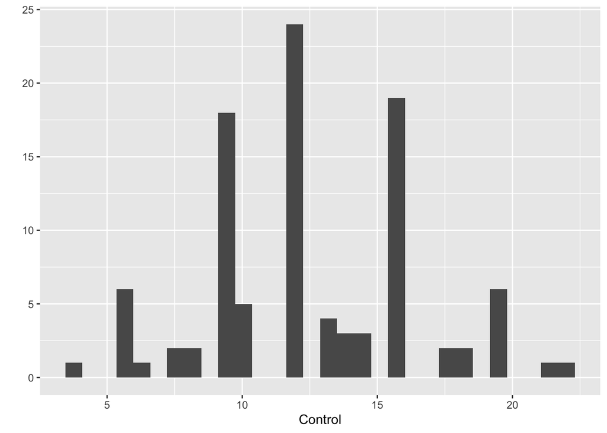

```r
new_df <- shuffle_data(df)

qplot(Control, data = new_df, geom = "histogram")
```

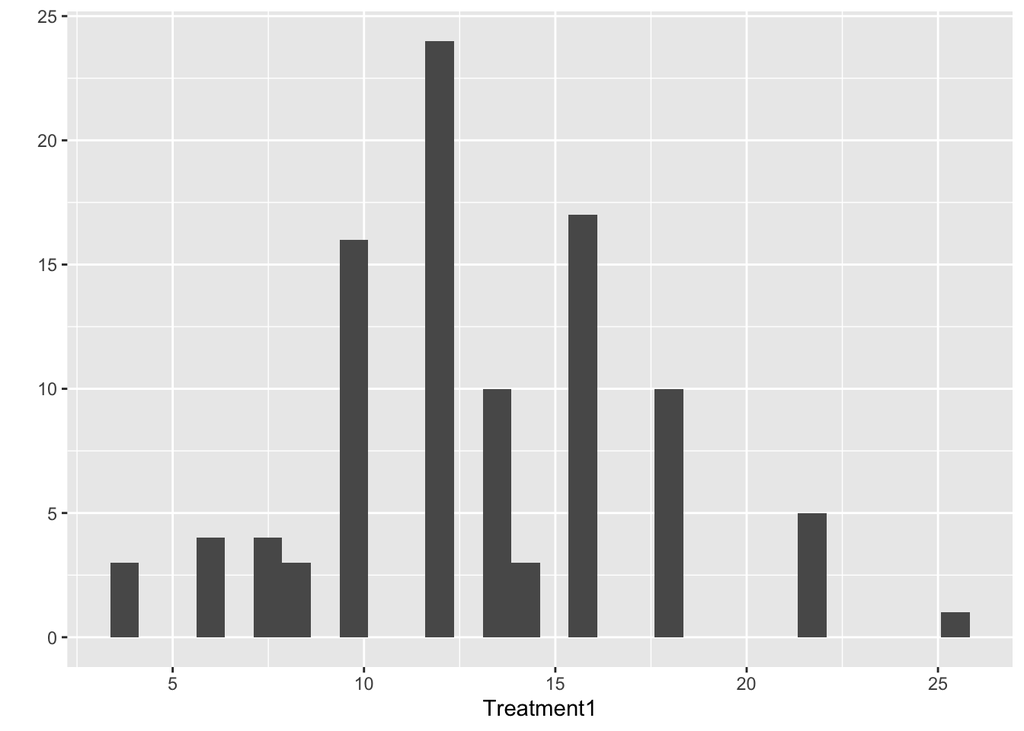

```r
qplot(Treatment1, data = new_df, geom = "histogram")
```

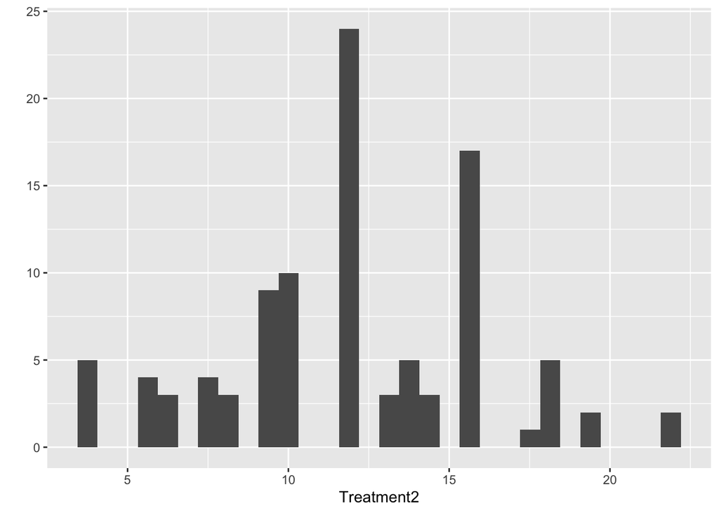

```r
qplot(Treatment2, data = new_df, geom = "histogram")
```